# Flights Data Exploration

## Preliminary Wrangling

> This document explores a dataset containing 7009728 records, reports flights in the United States, including carriers, arrival and departure delays, and reasons for delays in 2008

```python
# import all packages and set plots to be embedded inline
import numpy as np
import pandas as pd
import matplotlib.pyplot as plt
import seaborn as sb
import calendar

%matplotlib inline
```

```python
#Load in your dataset and describe its properties through the questions below.
#Try and motivate your exploration goals through this section.

flights = pd.read_csv('2008.csv')
pd.options.display.max_columns = 50
```

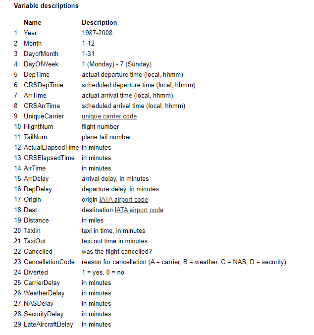

```python
# high-level overview of data shape and composition
print(flights.shape)
print(flights.dtypes)
print(flights.head(10))
```

```
(7009728, 29)
Year                   int64
Month                  int64
DayofMonth             int64
DayOfWeek              int64
DepTime              float64
CRSDepTime             int64
ArrTime              float64
CRSArrTime             int64
UniqueCarrier         object
FlightNum              int64
TailNum               object
ActualElapsedTime    float64
CRSElapsedTime       float64
AirTime              float64
ArrDelay             float64
DepDelay             float64
Origin                object
Dest                  object
Distance               int64
TaxiIn               float64
TaxiOut              float64
Cancelled              int64
CancellationCode      object
Diverted               int64
CarrierDelay         float64
WeatherDelay         float64
NASDelay             float64
SecurityDelay        float64
LateAircraftDelay    float64
dtype: object
   Year  Month  DayofMonth  DayOfWeek  DepTime  CRSDepTime  ArrTime  \
0  2008      1           3          4   2003.0        1955   2211.0
1  2008      1           3          4    754.0         735   1002.0
2  2008      1           3          4    628.0         620    804.0
3  2008      1           3          4    926.0         930   1054.0
4  2008      1           3          4   1829.0        1755   1959.0
5  2008      1           3          4   1940.0        1915   2121.0
6  2008      1           3          4   1937.0        1830   2037.0
7  2008      1           3          4   1039.0        1040   1132.0
```

[output cut: 35 more lines]

```
7      7.0          0              NaN         0           NaN           NaN
8     19.0          0              NaN         0           NaN           NaN
9      6.0          0              NaN         0           NaN           NaN

   NASDelay  SecurityDelay  LateAircraftDelay
0       NaN            NaN                NaN
1       NaN            NaN                NaN
2       NaN            NaN                NaN
3       NaN            NaN                NaN
4       0.0            0.0               32.0
5       NaN            NaN                NaN
6       0.0            0.0               47.0
7       NaN            NaN                NaN
8       NaN            NaN                NaN
9       NaN            NaN                NaN
```

```python
# Fix the data format because the original format does not have even leading digit (4 digit). Example: 945 instead of 0945.

flights.DepTime = flights.DepTime.apply(lambda x: str(int(x)).zfill(4) if pd.notnull(x) else x)
flights.CRSDepTime = flights.CRSDepTime.apply(lambda x: str(int(x)).zfill(4) if pd.notnull(x) else x)
flights.ArrTime = flights.ArrTime.apply(lambda x: str(int(x)).zfill(4) if pd.notnull(x) else x)
flights.CRSArrTime = flights.CRSArrTime.apply(lambda x: str(int(x)).zfill(4) if pd.notnull(x) else x)
```

```python
# convert month int to month name
flights['Month'] = flights['Month'].apply(lambda x: calendar.month_abbr[x])

# convert DayOfWeek int to DayOfWeek name
flights['DayOfWeek'] = flights['DayOfWeek'] -1
flights['DayOfWeek'] = flights['DayOfWeek'].apply(lambda x: calendar.day_abbr[x])
```

```python
## Create a new column DelayElapsedTime from ActualElapsedTime and CRSElapsedTime
flights["DelayElapsedTime"] = flights.ActualElapsedTime - flights.CRSElapsedTime
```

```python
# "ArrDelay = DepDelay + DelayElapsedTime"  or "ArrDelay - DepDelay - DelayElapsedTime = 0"
flights_df = flights[(flights.ArrDelay-flights.DepDelay-flights.DelayElapsedTime)==0]
```

```python
flights_df.shape
```

```
(6854996, 30)
```

```python
flights_df.describe()
```

|  | Year | DayofMonth | FlightNum | ActualElapsedTime | CRSElapsedTime | AirTime | ArrDelay | DepDelay | Distance | TaxiIn | TaxiOut | Cancelled | Diverted | CarrierDelay | WeatherDelay | NASDelay | SecurityDelay | LateAircraftDelay | DelayElapsedTime |
| --- | --- | --- | --- | --- | --- | --- | --- | --- | --- | --- | --- | --- | --- | --- | --- | --- | --- | --- | --- |
| count | 6854996.0 | 6.854996e+06 | 6.854996e+06 | 6.854996e+06 | 6.854996e+06 | 6.854996e+06 | 6.854996e+06 | 6.854996e+06 | 6.854996e+06 | 6.854996e+06 | 6.854996e+06 | 6854996.0 | 6854996.0 | 1.524725e+06 | 1.524725e+06 | 1.524725e+06 | 1.524725e+06 | 1.524725e+06 | 6.854996e+06 |
| mean | 2008.0 | 1.573825e+01 | 2.212516e+03 | 1.273226e+02 | 1.290780e+02 | 1.040187e+02 | 8.168431e+00 | 9.923803e+00 | 7.287448e+02 | 6.860158e+00 | 1.644370e+01 | 0.0 | 0.0 | 1.577188e+01 | 3.039051e+00 | 1.716472e+01 | 7.497483e-02 | 2.077090e+01 | -1.755372e+00 |
| std | 0.0 | 8.801090e+00 | 1.956438e+03 | 7.018740e+01 | 6.953282e+01 | 6.743990e+01 | 3.850186e+01 | 3.520377e+01 | 5.632457e+02 | 4.931232e+00 | 1.131064e+01 | 0.0 | 0.0 | 4.009884e+01 | 1.950294e+01 | 3.189503e+01 | 1.837946e+00 | 3.925968e+01 | 1.403090e+01 |
| min | 2008.0 | 1.000000e+00 | 1.000000e+00 | 1.200000e+01 | -1.410000e+02 | 0.000000e+00 | -5.190000e+02 | -5.340000e+02 | 1.100000e+01 | 0.000000e+00 | 0.000000e+00 | 0.0 | 0.0 | 0.000000e+00 | 0.000000e+00 | 0.000000e+00 | 0.000000e+00 | 0.000000e+00 | -1.810000e+02 |
| 25% | 2008.0 | 8.000000e+00 | 6.180000e+02 | 7.700000e+01 | 8.000000e+01 | 5.500000e+01 | -1.000000e+01 | -4.000000e+00 | 3.260000e+02 | 4.000000e+00 | 1.000000e+01 | 0.0 | 0.0 | 0.000000e+00 | 0.000000e+00 | 0.000000e+00 | 0.000000e+00 | 0.000000e+00 | -9.000000e+00 |
| 50% | 2008.0 | 1.600000e+01 | 1.563000e+03 | 1.100000e+02 | 1.110000e+02 | 8.600000e+01 | -2.000000e+00 | -1.000000e+00 | 5.810000e+02 | 6.000000e+00 | 1.400000e+01 | 0.0 | 0.0 | 0.000000e+00 | 0.000000e+00 | 6.000000e+00 | 0.000000e+00 | 0.000000e+00 | -3.000000e+00 |
| 75% | 2008.0 | 2.300000e+01 | 3.494000e+03 | 1.570000e+02 | 1.590000e+02 | 1.320000e+02 | 1.200000e+01 | 8.000000e+00 | 9.540000e+02 | 8.000000e+00 | 1.900000e+01 | 0.0 | 0.0 | 1.600000e+01 | 0.000000e+00 | 2.100000e+01 | 0.000000e+00 | 2.600000e+01 | 4.000000e+00 |
| max | 2008.0 | 3.100000e+01 | 9.741000e+03 | 1.379000e+03 | 6.600000e+02 | 1.350000e+03 | 2.461000e+03 | 2.467000e+03 | 4.962000e+03 | 3.080000e+02 | 4.290000e+02 | 0.0 | 0.0 | 2.436000e+03 | 1.352000e+03 | 1.357000e+03 | 3.920000e+02 | 1.316000e+03 | 1.034000e+03 |

```python
flights_df.head()
```

|  | Year | Month | DayofMonth | DayOfWeek | DepTime | CRSDepTime | ArrTime | CRSArrTime | UniqueCarrier | FlightNum | TailNum | ActualElapsedTime | CRSElapsedTime | AirTime | ArrDelay | DepDelay | Origin | Dest | Distance | TaxiIn | TaxiOut | Cancelled | CancellationCode | Diverted | CarrierDelay | WeatherDelay | NASDelay | SecurityDelay | LateAircraftDelay | … |
| --- | --- | --- | --- | --- | --- | --- | --- | --- | --- | --- | --- | --- | --- | --- | --- | --- | --- | --- | --- | --- | --- | --- | --- | --- | --- | --- | --- | --- | --- | --- |
| 0 | 2008 | Jan | 3 | Thu | 2003 | 1955 | 2211 | 2225 | WN | 335 | N712SW | 128.0 | 150.0 | 116.0 | -14.0 | 8.0 | IAD | TPA | 810 | 4.0 | 8.0 | 0 | NaN | 0 | NaN | NaN | NaN | NaN | NaN | … |
| 1 | 2008 | Jan | 3 | Thu | 0754 | 0735 | 1002 | 1000 | WN | 3231 | N772SW | 128.0 | 145.0 | 113.0 | 2.0 | 19.0 | IAD | TPA | 810 | 5.0 | 10.0 | 0 | NaN | 0 | NaN | NaN | NaN | NaN | NaN | … |
| 2 | 2008 | Jan | 3 | Thu | 0628 | 0620 | 0804 | 0750 | WN | 448 | N428WN | 96.0 | 90.0 | 76.0 | 14.0 | 8.0 | IND | BWI | 515 | 3.0 | 17.0 | 0 | NaN | 0 | NaN | NaN | NaN | NaN | NaN | … |
| 3 | 2008 | Jan | 3 | Thu | 0926 | 0930 | 1054 | 1100 | WN | 1746 | N612SW | 88.0 | 90.0 | 78.0 | -6.0 | -4.0 | IND | BWI | 515 | 3.0 | 7.0 | 0 | NaN | 0 | NaN | NaN | NaN | NaN | NaN | … |
| 4 | 2008 | Jan | 3 | Thu | 1829 | 1755 | 1959 | 1925 | WN | 3920 | N464WN | 90.0 | 90.0 | 77.0 | 34.0 | 34.0 | IND | BWI | 515 | 3.0 | 10.0 | 0 | NaN | 0 | 2.0 | 0.0 | 0.0 | 0.0 | 32.0 | … |

### What is the structure of your dataset?

> There are 6854996 records with 30 columns. Most of the columns are numeric.

### What is/are the main feature(s) of interest in your dataset?

> Find the diffent factors behind the delay along with best Airport and best Airline in terms of Arrival or Departure delay.

### What features in the dataset do you think will help support your investigation into your feature(s) of interest?

> I expect that `ArrDelay`,`DepDelay`,`ActualElapsedTime`,`UniqueCarrier`,`Origin`,`Dest` will be the import featurs for this analysis.

## Univariate Exploration

#### 1. ArrDelay

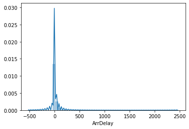

```python
sb.distplot(flights_df['ArrDelay'])
```

The distributuon of ArrDelay is right skewed and there is a very long tail of Flight ArrDelay. There are flights where ArrDelay is more than 2000 minutes.

```python
#Check for ourliers
flights_df[(flights_df.ArrDelay < -300) | (flights_df.ArrDelay > 1500)].shape
```

```
(10, 30)
```

```python
#Remove outliers
flights_df = flights_df[(flights_df.ArrDelay > -300) | (flights_df.ArrDelay < 1500)]
```

#### 2. DepDelay

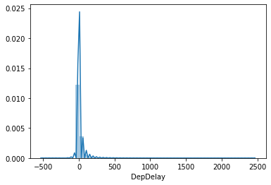

```python
sb.distplot(flights_df['DepDelay'])
```

The distributuon of DepDelay is right skewed and there is a very long tail of Flight DepDelay. There are flights where DepDelay is more than 2000 minutes.

```python
#Check for ourliers
flights_df[(flights_df.DepDelay < -300) | (flights_df.DepDelay > 1500)].shape
```

```
(10, 30)
```

```python
#Remove outliers
flights_df = flights_df[(flights_df.DepDelay > -300) | (flights_df.DepDelay < 1500)]
```

```python
flights_df.shape
```

```
(6854996, 30)
```

#### 3. DelayElapsedTime

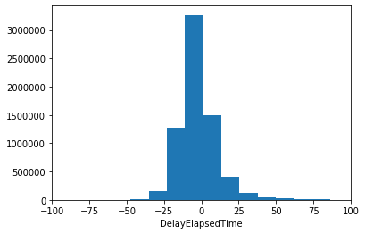

```python
plt.hist(data = flights_df, x = "DelayElapsedTime", bins = 100)
plt.xlabel("DelayElapsedTime");
plt.xlim([-100,100]);
```

The distribution looks normal to me and most of the time ActualElapsedTime is equal to CRSElapsedTime

#### 4. Distribution of different Carriers

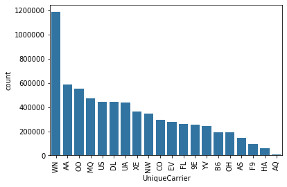

```python
Carrier_order = flights_df.UniqueCarrier.value_counts().index;
base_color = sb.color_palette()[0]
sb.countplot(data = flights_df, x = 'UniqueCarrier', color = base_color,order = Carrier_order)
plt.xticks(rotation = 90)
```

WN was the most common airline in US in 2008.

### Of the features you investigated, were there any unusual distributions? Did you perform any operations on the data to tidy, adjust, or change the form of the data? If so, why did you do this?

> `DelayElapsedTime` = `ActualElapsedTime` - `CRSElapsedTime`

`DelayElapsedTime` was normally distributed.

I also kept only those entires in the dataset which meet below formula.

`ArrDelay` - `DepDelay` - `DelayElapsedTime` = 0

## Bivariate Exploration

> In this section, investigate relationships between pairs of variables in your data. Make sure the variables that you cover here have been introduced in some fashion in the previous section (univariate exploration).

#### 1. Arrival Delay, Departure Delay, DelayElapsedTime vs Distance

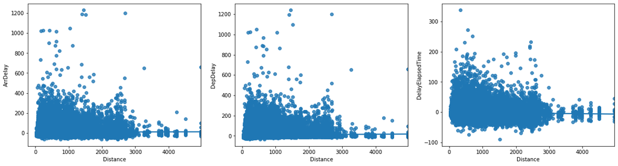

```python
sample_df = flights_df.sample(100000)

plt.figure(figsize=[20,5])

plt.subplot(1,3,1)
sb.regplot(data = sample_df, x = 'Distance', y = 'ArrDelay')

plt.subplot(1,3,2)
sb.regplot(data = sample_df, x = 'Distance', y = 'DepDelay')

plt.subplot(1,3,3)
sb.regplot(data = sample_df, x = 'Distance', y = 'DelayElapsedTime')
```

#### 2. Arrival Delay vs Day of Week

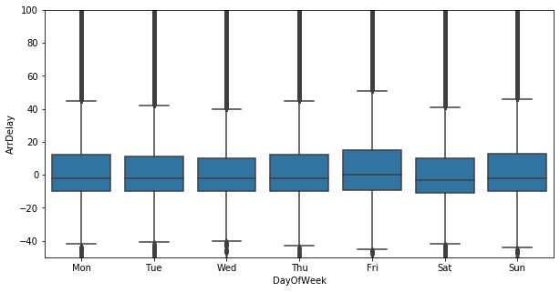

```python
group_order = ['Mon','Tue','Wed','Thu','Fri','Sat','Sun']
plt.figure(figsize = [10, 5])
base_color = sb.color_palette()[0]
sb.boxplot(data = sample_df, x = 'DayOfWeek', y = 'ArrDelay', color = base_color, order=group_order)
plt.ylim(-50,100);
```

Its seems like flights arrival delayed are more on Friday.

#### 3. In which month flights are more delayed ?

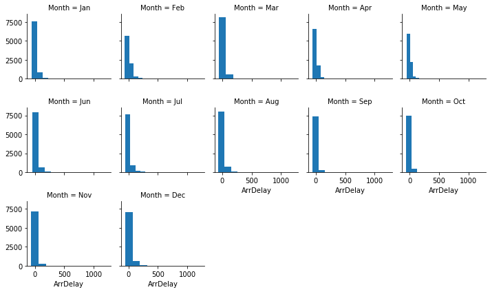

```python
group_order = ['Jan','Feb','Mar','Apr','May','Jun','Jul','Aug','Sep','Oct','Nov','Dec']


g = sb.FacetGrid(data = sample_df, col = 'Month', col_wrap = 5, size = 2,col_order=group_order)
g.map(plt.hist, "ArrDelay")
```

```python
sample_df.head(5)
```

|  | Year | Month | DayofMonth | DayOfWeek | DepTime | CRSDepTime | ArrTime | CRSArrTime | UniqueCarrier | FlightNum | TailNum | ActualElapsedTime | CRSElapsedTime | AirTime | ArrDelay | DepDelay | Origin | Dest | Distance | TaxiIn | TaxiOut | Cancelled | CancellationCode | Diverted | CarrierDelay | WeatherDelay | NASDelay | SecurityDelay | LateAircraftDelay | … |
| --- | --- | --- | --- | --- | --- | --- | --- | --- | --- | --- | --- | --- | --- | --- | --- | --- | --- | --- | --- | --- | --- | --- | --- | --- | --- | --- | --- | --- | --- | --- |
| 4098598 | 2008 | Jul | 29 | Tue | 1721 | 1655 | 2008 | 1950 | AA | 181 | N321AA | 347.0 | 355.0 | 307.0 | 18.0 | 26.0 | JFK | LAX | 2475 | 3.0 | 37.0 | 0 | NaN | 0 | 0.0 | 0.0 | 1.0 | 0.0 | 17.0 | … |
| 3257259 | 2008 | Jun | 3 | Tue | 1751 | 1755 | 2018 | 2006 | US | 808 | N919UW | 147.0 | 131.0 | 102.0 | 12.0 | -4.0 | CLT | BOS | 728 | 7.0 | 38.0 | 0 | NaN | 0 | NaN | NaN | NaN | NaN | NaN | … |
| 2917401 | 2008 | May | 12 | Mon | 1225 | 1225 | 1815 | 1825 | AA | 2400 | N4YRAA | 230.0 | 240.0 | 206.0 | -10.0 | 0.0 | SEA | ORD | 1721 | 5.0 | 19.0 | 0 | NaN | 0 | NaN | NaN | NaN | NaN | NaN | … |
| 3364787 | 2008 | Jun | 23 | Mon | 1707 | 1658 | 1758 | 1747 | FL | 781 | N927AT | 111.0 | 109.0 | 79.0 | 11.0 | 9.0 | ATL | STL | 483 | 3.0 | 29.0 | 0 | NaN | 0 | NaN | NaN | NaN | NaN | NaN | … |
| 6157139 | 2008 | Nov | 9 | Sun | 0941 | 0942 | 1148 | 1206 | UA | 1497 | N478UA | 127.0 | 144.0 | 112.0 | -18.0 | -1.0 | ORD | MSY | 837 | 3.0 | 12.0 | 0 | NaN | 0 | NaN | NaN | NaN | NaN | NaN | … |

#### 4. Average Departure Delay of different Airlines

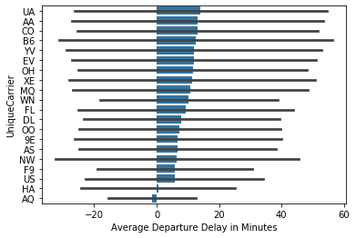

```python
THRESHOLD = 1000
make_frequency = flights_df['UniqueCarrier'].value_counts()
idx = np.sum(make_frequency > THRESHOLD)

most_makes = make_frequency.index[:idx]
flights_df_sub = flights_df.loc[flights_df['UniqueCarrier'].isin(most_makes)]

make_means = flights_df_sub.groupby('UniqueCarrier').mean()
comb_order = make_means.sort_values('DepDelay', ascending = False).index

# plotting
base_color = sb.color_palette()[0]
sb.barplot(data = flights_df_sub, x = 'DepDelay', y = 'UniqueCarrier',
           color = base_color, order = comb_order, ci = 'sd')
plt.xlabel('Average Departure Delay in Minutes')
```

#### 5. Different Carriers in 2008 for which Departure delay is more than 1 hour

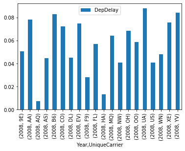

```python
flights_df.groupby(['Year', 'UniqueCarrier']).agg({'DepDelay':lambda x: (x>60).sum()/len(x)}).plot.bar()
plt.show()
```

## Multivariate Exploration

> Create plots of three or more variables to investigate your data even further. Make sure that your investigations are justified, and follow from your work in the previous sections.

#### 1. Explore relation between ArrDelay, DepDelay and DelayElapsedTime

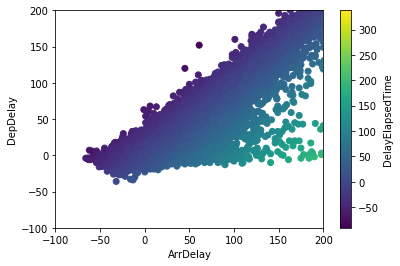

```python
plt.scatter(data = sample_df, x = 'ArrDelay', y = 'DepDelay', c = 'DelayElapsedTime')

    # plottingplt.figure(figsize = [8,6])
plt.colorbar(label = 'DelayElapsedTime')
plt.xlim(-100,200)
plt.ylim(-100,200)
plt.xlabel('ArrDelay')
plt.ylabel('DepDelay')
```

#### 2. Exploring Average Arrival delay in each month for year 2008

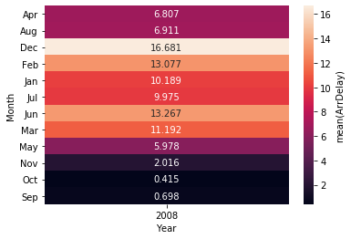

```python
cat_means = flights_df.groupby(['Year', 'Month']).mean()['ArrDelay']
cat_means = cat_means.reset_index(name = 'num_var2_avg')
cat_means = cat_means.pivot(index = 'Month', columns = 'Year',
                            values = 'num_var2_avg')
sb.heatmap(cat_means, annot = True, fmt = '.3f',
           cbar_kws = {'label' : 'mean(ArrDelay)'})
```

From above result we can conclude that Averge arrival dealy was highest in the month of December.

#### 3. Exploring relation between DepDelay and ArrDelay based on UniqueCarrier

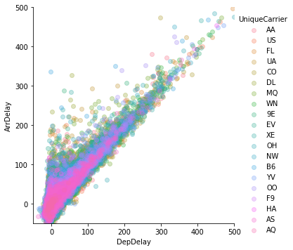

```python
sb.lmplot('DepDelay', 'ArrDelay', data=sample_df,
           fit_reg=False, hue='UniqueCarrier', scatter_kws={'alpha':0.3})
plt.xlim([-50,500]);
plt.ylim([-50,500]);
plt.show()
```

Above result shows a positive relationship between DepDelay and ArrDelay

#### 4 Different reasons behind the flight delay in 2008

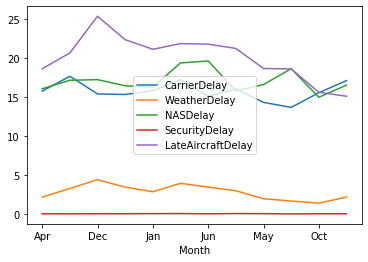

```python
flights_df.groupby('Month').agg({'CarrierDelay':'mean', 'WeatherDelay':'mean','NASDelay':'mean','SecurityDelay':'mean','LateAircraftDelay':'mean'}).plot.line()
plt.show()
```

Above figure depict that LateAircraftDelay is most common reason behind the delay

### Talk about some of the relationships you observed in this part of the investigation. Were there features that strengthened each other in terms of looking at your feature(s) of interest?

> I found that there is a postive relationship between DepDelay and ArrDelay and ArrDelay Increase alsong with DelayElapsedTime.